```python
# Parameter cell

csv_dir = '/Users/martaarnabatmartin/Desktop/Pipelines/UCHardLanding/pipeline/data/artifacts/validation_GradientBoosting'
model_name = 'GradientBoosting'
subsample_size = 300
splitting_variables = ['I1', 'I2', 'I3', 'I4', 'I5', 'I6', 'I7']
```

# Model validation. Offline evaluation

```python
# Importing the libraries
from IPython.display import Markdown
import os, json, numpy as np, pandas as pd, matplotlib.pyplot as plt
import scipy.stats as st

import validationlib
import validationlib.models.validation
```

```python
if model_name is not None:
    display(Markdown(f"## Model: {model_name}"))
```

Model: GradientBoosting

```python
# Load dataframes

x_train_df = pd.read_csv(os.path.join(csv_dir, "x_train.csv"))
x_test_df = pd.read_csv(os.path.join(csv_dir, "x_test.csv"))
x_val_df = pd.read_csv(os.path.join(csv_dir, "x_val.csv"))

yt_train_df = pd.read_csv(os.path.join(csv_dir, "yt_train.csv"))
yt_test_df = pd.read_csv(os.path.join(csv_dir, "yt_test.csv"))
yt_val_df = pd.read_csv(os.path.join(csv_dir, "yt_val.csv"))

yh_val_df = pd.read_csv(os.path.join(csv_dir, "yh_val.csv"))
yh_test_df = pd.read_csv(os.path.join(csv_dir, "yh_test.csv"))
```

```python
# Subsample the data (use only n random examples from each set)
if subsample_size is not None:
    n = subsample_size
    display(Markdown(f"### *Subsampling to {n} examples per set*"))
    train_indices = np.random.choice(x_train_df.index, n, replace=False)
    test_indices = np.random.choice(x_test_df.index, n, replace=False)
    val_indices = np.random.choice(x_val_df.index, n, replace=False)

    x_train_df = x_train_df.loc[train_indices]
    x_test_df = x_test_df.loc[test_indices]
    x_val_df = x_val_df.loc[val_indices]

    yt_train_df = yt_train_df.loc[train_indices]
    yt_test_df = yt_test_df.loc[test_indices]
    yt_val_df = yt_val_df.loc[val_indices]

    yh_val_df = yh_val_df.loc[val_indices]
    yh_test_df = yh_test_df.loc[test_indices]
```

*Subsampling to 300 examples per set*

```python
if splitting_variables is None:
    splitting_variables = x_train_df.columns.tolist()
```

```python
input_names = x_train_df.columns
output_names = yt_train_df.columns
```

```python
# # Get all the test data that has the same splitting variables as the training data and remove it from the test set
# used_test_indices = ~x_test_df.set_index(splitting_variables).index.isin(x_train_df.set_index(splitting_variables).index)
# used_val_indices = ~x_val_df.set_index(splitting_variables).index.isin(x_train_df.set_index(splitting_variables).index)

# x_test_df = x_test_df[used_test_indices]
# yt_test_df = yt_test_df[used_test_indices]
# yh_test_df = yh_test_df[used_test_indices]

# x_val_df = x_val_df[used_val_indices]
# yt_val_df = yt_val_df[used_val_indices]
# yh_val_df = yh_val_df[used_val_indices]
```

```python
spvar_train = np.array(list(x_train_df.groupby(splitting_variables).groups.keys()))
spvar_test = np.array(list(x_test_df.groupby(splitting_variables).groups.keys()))
spvar_val = np.array(list(x_val_df.groupby(splitting_variables).groups.keys()))

if len(splitting_variables) == 2:
    fig, axs = plt.subplots(figsize=(10,10))
    axs.scatter(spvar_train[:, 0], spvar_train[:, 1], label="Train", facecolors="none", edgecolors="tab:blue", s=100)
    axs.scatter(spvar_test[:, 0], spvar_test[:, 1], label="Test", marker="+", s=100, c="tab:orange")
    axs.scatter(spvar_val[:, 0], spvar_val[:, 1], label="Validation", marker="x", s=100, c="tab:green")
    axs.set_xlabel(splitting_variables[0])
    axs.set_ylabel(splitting_variables[1])
    plt.legend()
    plt.show()
```

## DATA

```python
# Since the data is already splited in training, validation and test, we merge all the subsets for this analysis
x_df = pd.concat([x_train_df, x_val_df, x_test_df], axis=0)
yt_df = pd.concat([yt_train_df, yt_val_df, yt_test_df], axis=0)
```

#### INPUTS

Confidence level at 95%. BS=Confidence Interval (percentile bootstrap)

|  | count | min | max | mean | (BS)mean | median | (BS)median | std | (BS)std | IQR | (BS)IQR | kurtosis | (BS)kurtosis | skewness | (BS)skewness |
| --- | --- | --- | --- | --- | --- | --- | --- | --- | --- | --- | --- | --- | --- | --- | --- |
| I1 | 900 | 0.165 | 1.00 | 0.529 | <sup>0.547</sup><sub>0.515</sub> | 0.494 | <sup>0.537</sup><sub>0.494</sub> | 0.226 | <sup>0.237</sup><sub>0.216</sub> | 0.288 | <sup>0.35</sup><sub>0.267</sub> | -0.0813 | <sup>0.141</sup><sub>-0.306</sub> | 0.557 | <sup>0.641</sup><sub>0.446</sub> |
| I2 | 900 | 0.00 | 0.964 | 0.309 | <sup>0.328</sup><sub>0.294</sub> | 0.273 | <sup>0.273</sup><sub>0.273</sub> | 0.238 | <sup>0.246</sup><sub>0.228</sub> | 0.364 | <sup>0.455</sup><sub>0.364</sub> | -0.49 | <sup>-0.247</sup><sub>-0.736</sub> | 0.547 | <sup>0.645</sup><sub>0.404</sub> |
| I3 | 900 | 0.154 | 0.923 | 0.466 | <sup>0.480</sup><sub>0.451</sub> | 0.385 | <sup>0.385</sup><sub>0.385</sub> | 0.245 | <sup>0.252</sup><sub>0.237</sub> | 0.462 | <sup>0.462</sup><sub>0.385</sub> | -1.10 | <sup>-0.979</sup><sub>-1.23</sub> | 0.479 | <sup>0.578</sup><sub>0.376</sub> |
| I4 | 900 | 0.133 | 0.930 | 0.467 | <sup>0.485</sup><sub>0.454</sub> | 0.333 | <sup>0.533</sup><sub>0.333</sub> | 0.290 | <sup>0.299</sup><sub>0.283</sub> | 0.400 | <sup>0.797</sup><sub>0.200</sub> | -1.04 | <sup>-0.905</sup><sub>-1.21</sub> | 0.51 | <sup>0.587</sup><sub>0.410</sub> |
| I5 | 900 | -0.667 | 0.667 | 0.00519 | <sup>0.0415</sup><sub>-0.0286</sub> | 0.00 | <sup>0.00</sup><sub>0.00</sub> | 0.535 | <sup>0.548</sup><sub>0.522</sub> | 1.33 | <sup>1.33</sup><sub>1.33</sub> | -1.45 | <sup>-1.37</sup><sub>-1.52</sub> | -0.0140 | <sup>0.0779</sup><sub>-0.114</sub> |
| I6 | 900 | 0.00 | 1.00 | 0.274 | <sup>0.299</sup><sub>0.252</sub> | 0.00 | <sup>0.00</sup><sub>0.00</sub> | 0.446 | <sup>0.458</sup><sub>0.434</sub> | 1.00 | <sup>1.00</sup><sub>1.00</sub> | -0.978 | <sup>-0.69</sup><sub>-1.23</sub> | 1.01 | <sup>1.14</sup><sub>0.876</sub> |
| I7 | 900 | 0.0224 | 0.849 | 0.358 | <sup>0.369</sup><sub>0.350</sub> | 0.354 | <sup>0.364</sup><sub>0.344</sub> | 0.163 | <sup>0.169</sup><sub>0.157</sub> | 0.228 | <sup>0.245</sup><sub>0.212</sub> | -0.495 | <sup>-0.285</sup><sub>-0.66</sub> | 0.118 | <sup>0.203</sup><sub>0.0197</sub> |

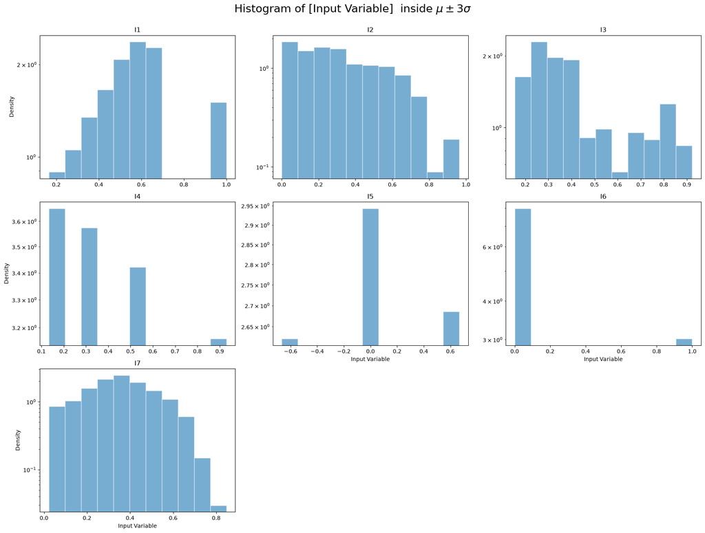

Confidence level at 95%. BS=Confidence Interval (percentile bootstrap)

|  | 1% | (BS)1% | 5% | (BS)5% | 10% | (BS)10% | 50% | (BS)50% | 90% | (BS)90% | 95% | (BS)95% | 99% | (BS)99% |
| --- | --- | --- | --- | --- | --- | --- | --- | --- | --- | --- | --- | --- | --- | --- |
| I1 | 0.165 | <sup>0.165</sup><sub>0.165</sub> | 0.165 | <sup>0.165</sup><sub>0.165</sub> | 0.247 | <sup>0.247</sup><sub>0.247</sub> | 0.494 | <sup>0.494</sup><sub>0.494</sub> | 1.00 | <sup>1.00</sup><sub>0.679</sub> | 1.00 | <sup>1.00</sup><sub>1.00</sub> | 1.00 | <sup>1.00</sup><sub>1.00</sub> |
| I2 | 0.00 | <sup>0.00</sup><sub>0.00</sub> | 0.00 | <sup>0.00</sup><sub>0.00</sub> | 0.00 | <sup>0.00</sup><sub>0.00</sub> | 0.273 | <sup>0.273</sup><sub>0.273</sub> | 0.636 | <sup>0.636</sup><sub>0.636</sub> | 0.727 | <sup>0.75</sup><sub>0.727</sub> | 0.964 | <sup>0.964</sup><sub>0.82</sub> |
| I3 | 0.154 | <sup>0.154</sup><sub>0.154</sub> | 0.154 | <sup>0.154</sup><sub>0.154</sub> | 0.154 | <sup>0.231</sup><sub>0.154</sub> | 0.385 | <sup>0.385</sup><sub>0.385</sub> | 0.846 | <sup>0.846</sup><sub>0.846</sub> | 0.923 | <sup>0.923</sup><sub>0.846</sub> | 0.923 | <sup>0.923</sup><sub>0.923</sub> |
| I4 | 0.133 | <sup>0.133</sup><sub>0.133</sub> | 0.133 | <sup>0.133</sup><sub>0.133</sub> | 0.133 | <sup>0.133</sup><sub>0.133</sub> | 0.333 | <sup>0.533</sup><sub>0.333</sub> | 0.930 | <sup>0.930</sup><sub>0.930</sub> | 0.930 | <sup>0.930</sup><sub>0.930</sub> | 0.930 | <sup>0.930</sup><sub>0.930</sub> |
| I5 | -0.667 | <sup>-0.667</sup><sub>-0.667</sub> | -0.667 | <sup>-0.667</sup><sub>-0.667</sub> | -0.667 | <sup>-0.667</sup><sub>-0.667</sub> | 0.00 | <sup>0.00</sup><sub>0.00</sub> | 0.667 | <sup>0.667</sup><sub>0.667</sub> | 0.667 | <sup>0.667</sup><sub>0.667</sub> | 0.667 | <sup>0.667</sup><sub>0.667</sub> |
| I6 | 0.00 | <sup>0.00</sup><sub>0.00</sub> | 0.00 | <sup>0.00</sup><sub>0.00</sub> | 0.00 | <sup>0.00</sup><sub>0.00</sub> | 0.00 | <sup>0.00</sup><sub>0.00</sub> | 1.00 | <sup>1.00</sup><sub>1.00</sub> | 1.00 | <sup>1.00</sup><sub>1.00</sub> | 1.00 | <sup>1.00</sup><sub>1.00</sub> |
| I7 | 0.0414 | <sup>0.0512</sup><sub>0.036</sub> | 0.0842 | <sup>0.0921</sup><sub>0.0725</sub> | 0.132 | <sup>0.147</sup><sub>0.111</sub> | 0.354 | <sup>0.365</sup><sub>0.342</sub> | 0.578 | <sup>0.597</sup><sub>0.56</sub> | 0.638 | <sup>0.658</sup><sub>0.616</sub> | 0.719 | <sup>0.738</sup><sub>0.692</sub> |

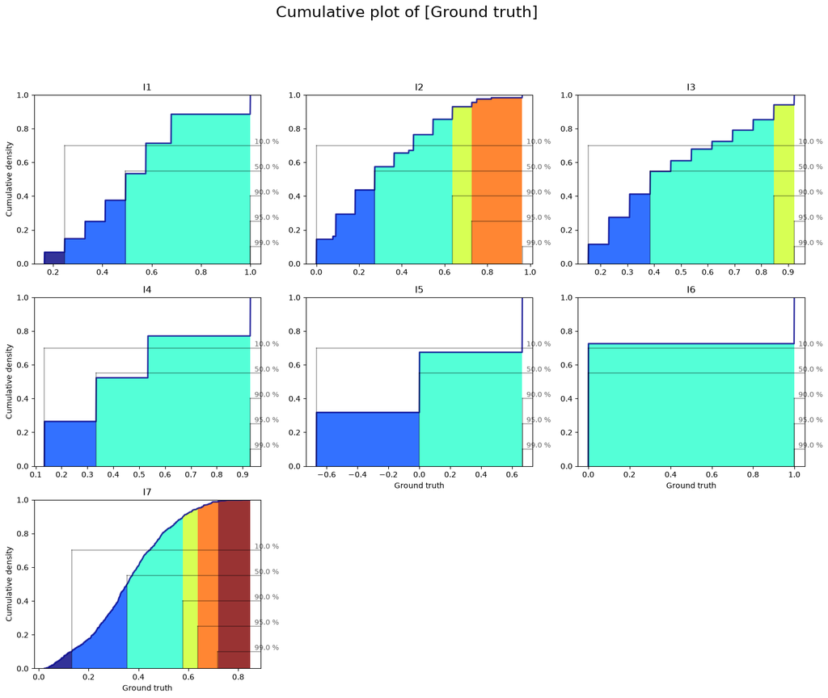

```python
statistics = {
    "mean": np.mean,
    "median": [np.percentile, {"q": 50}],
    "std": np.std,
    "IQR": st.iqr,
    "kurtosis": st.kurtosis,
    "skewness": st.skew
}
displayed_table = validationlib.tables.summary.prediction_stats(
    x_df, # Metric from which the statistics are calculated
    statistics=statistics, # Dictionary of statistics to calculate
    precision=3, # Number of decimal places to display in the table
    nsim=100, # Number of simulations for the bootstrap method
    method='Bootstrap' # Method used to calculate the confidence intervals.
)
display(displayed_table)

validationlib.plots.histogram(
    x_df,
    xlabel="Input Variable",
    trimStds=3,
    multiPlotsKwargs={"tight_layout": True},
    logscale=True
)
plt.show()

statistics_percentile = {"%i%%" % i: [np.percentile, {"q": i}] for i in [1,5,10,50,90,95,99]} # Dict of percentiles to calculate
displayed_table = validationlib.tables.summary.prediction_stats(
    x_df,
    statistics=statistics_percentile,
    precision=3,
    nsim=100,
    method='Bootstrap',
    countMinMax=False
)
display(displayed_table)

validationlib.plots.cumulative(
    x_df,
    xlabel="Ground truth",
    bins=1000,
    quantiles=[0.1, 0.50, 0.90, 0.95, 0.99] # Quantiles to display in the plot
)
plt.show()
```

#### OUTPUTS

Confidence level at 95%. BS=Confidence Interval (percentile bootstrap)

|  | count | min | max | mean | (BS)mean | median | (BS)median | std | (BS)std | IQR | (BS)IQR | kurtosis | (BS)kurtosis | skewness | (BS)skewness |
| --- | --- | --- | --- | --- | --- | --- | --- | --- | --- | --- | --- | --- | --- | --- | --- |
| O1 | 900 | 0.079 | 0.814 | 0.427 | <sup>0.436</sup><sub>0.416</sub> | 0.431 | <sup>0.438</sup><sub>0.42</sub> | 0.154 | <sup>0.160</sup><sub>0.147</sub> | 0.219 | <sup>0.24</sup><sub>0.201</sub> | -0.574 | <sup>-0.41</sup><sub>-0.70</sub> | 0.0290 | <sup>0.122</sup><sub>-0.0853</sub> |
| O2 | 900 | 0.104 | 0.775 | 0.336 | <sup>0.343</sup><sub>0.329</sub> | 0.335 | <sup>0.344</sup><sub>0.326</sub> | 0.119 | <sup>0.124</sup><sub>0.115</sub> | 0.174 | <sup>0.186</sup><sub>0.163</sub> | -0.229 | <sup>0.263</sup><sub>-0.538</sub> | 0.298 | <sup>0.458</sup><sub>0.159</sub> |

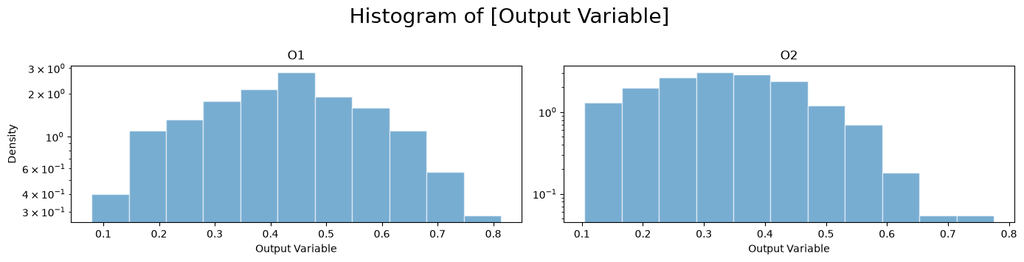

Confidence level at 95%. BS=Confidence Interval (percentile bootstrap)

|  | 1% | (BS)1% | 5% | (BS)5% | 10% | (BS)10% | 50% | (BS)50% | 90% | (BS)90% | 95% | (BS)95% | 99% | (BS)99% |
| --- | --- | --- | --- | --- | --- | --- | --- | --- | --- | --- | --- | --- | --- | --- |
| O1 | 0.123 | <sup>0.132</sup><sub>0.0954</sub> | 0.173 | <sup>0.182</sup><sub>0.161</sub> | 0.215 | <sup>0.228</sup><sub>0.195</sub> | 0.431 | <sup>0.439</sup><sub>0.421</sub> | 0.630 | <sup>0.640</sup><sub>0.621</sub> | 0.688 | <sup>0.700</sup><sub>0.649</sub> | 0.766 | <sup>0.791</sup><sub>0.749</sub> |
| O2 | 0.120 | <sup>0.128</sup><sub>0.115</sub> | 0.150 | <sup>0.157</sup><sub>0.146</sub> | 0.179 | <sup>0.188</sup><sub>0.166</sub> | 0.335 | <sup>0.344</sup><sub>0.326</sub> | 0.493 | <sup>0.504</sup><sub>0.477</sub> | 0.541 | <sup>0.555</sup><sub>0.515</sub> | 0.620 | <sup>0.668</sup><sub>0.591</sub> |

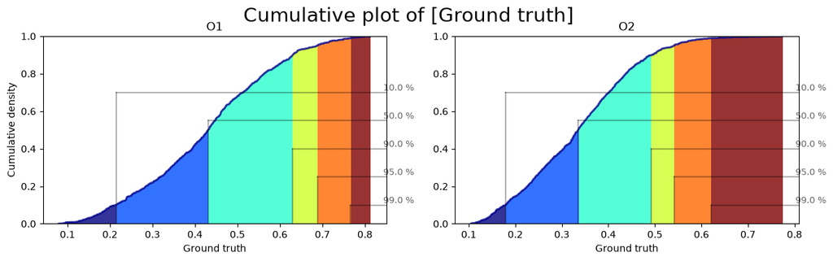

```python
statistics = {
    "mean": np.mean,
    "median": [np.percentile, {"q": 50}],
    "std": np.std,
    "IQR": st.iqr,
    "kurtosis": st.kurtosis,
    "skewness": st.skew
}
displayed_table = validationlib.tables.summary.prediction_stats(
    yt_df, # Metric from which the statistics are calculated
    statistics=statistics, # Dictionary of statistics to calculate
    precision=3, # Number of decimal places to display in the table
    nsim=100, # Number of simulations for the bootstrap method
    method='Bootstrap' # Method used to calculate the confidence intervals.
)
display(displayed_table)
validationlib.plots.histogram(
    yt_df,
    xlabel="Output Variable",
    multiPlotsKwargs={"tight_layout": True},
    logscale=True
)
plt.show()

statistics_percentile = {"%i%%" % i: [np.percentile, {"q": i}] for i in [1,5,10,50,90,95,99]} # Dict of percentiles to calculate
displayed_table = validationlib.tables.summary.prediction_stats(
    yt_df,
    statistics=statistics_percentile,
    precision=3,
    nsim=100,
    method='Bootstrap',
    countMinMax=False
)
display(displayed_table)

validationlib.plots.cumulative(
    yt_df,
    xlabel="Ground truth",
    bins=1000,
    quantiles=[0.1, 0.50, 0.90, 0.95, 0.99] # Quantiles to display in the plot
)
plt.show()
```

## TRAIN-TEST SPLIT

To check if the splitting in train and test is correctly done, we compare the distributions of inputs and outputs between the training and test set. The empirical distributions of training and test should resemble eachother (as we want the results obtained from the test set to be representative of the performance of the model), without being too similar (as there would be risk of p-hacking: the results obtained from the test set would not representative of the model's inference power, as it would have been tested in data excesively similar to the data it has been trained on).

To compare these distributions we:

- Plot a double histogram. The histogram of the test set should look alike the one of the training set.
- Perform hypothesis tests. Specificallly, we perform a two-sample Kolmogorov-Smirnov (KS) and Anderson-Darling (AD) tests. These tests consider as null hypothesis that both datasets come from the same distribution (and as alternative, that they do not).

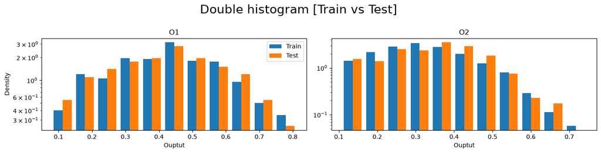

p-values

|  | KS | AD |
| --- | --- | --- |
| O1 | 0.99930 | 0.25000 |
| O2 | 0.01616 | 0.07198 |

```python
# Train-test split
validationlib.plots.doubleHistogram(
    yt_train_df,
    yt_test_df,
    xlabel='Ouptut',
    x1label='Train',
    x2label='Test',
    multiPlotsKwargs = {"tight_layout":True},
    logscale=True
)
plt.show()

table_pval_num = validationlib.tests.dist.dist_similarity_table(
    yt_train_df,
    yt_test_df,
    title="p-values",
    tests=["KS", "AD"]
)
display(table_pval_num)
```

```python
display(Markdown(f"Since the splitting is done by the variables {splitting_variables}, the TT split check should be done by the same variables"))

x_train_spvar_df = pd.DataFrame(x_train_df.groupby(splitting_variables).groups.keys(), columns=splitting_variables)
x_test_spvar_df = pd.DataFrame(x_test_df.groupby(splitting_variables).groups.keys(), columns=splitting_variables)
x_val_spvar_df = pd.DataFrame(x_val_df.groupby(splitting_variables).groups.keys(), columns=splitting_variables)
```

Since the splitting is done by the variables ['I1', 'I2', 'I3', 'I4', 'I5', 'I6', 'I7'], the TT split check should be done by the same variables

Comparison between train and test distributions of numerical variables (histograms)

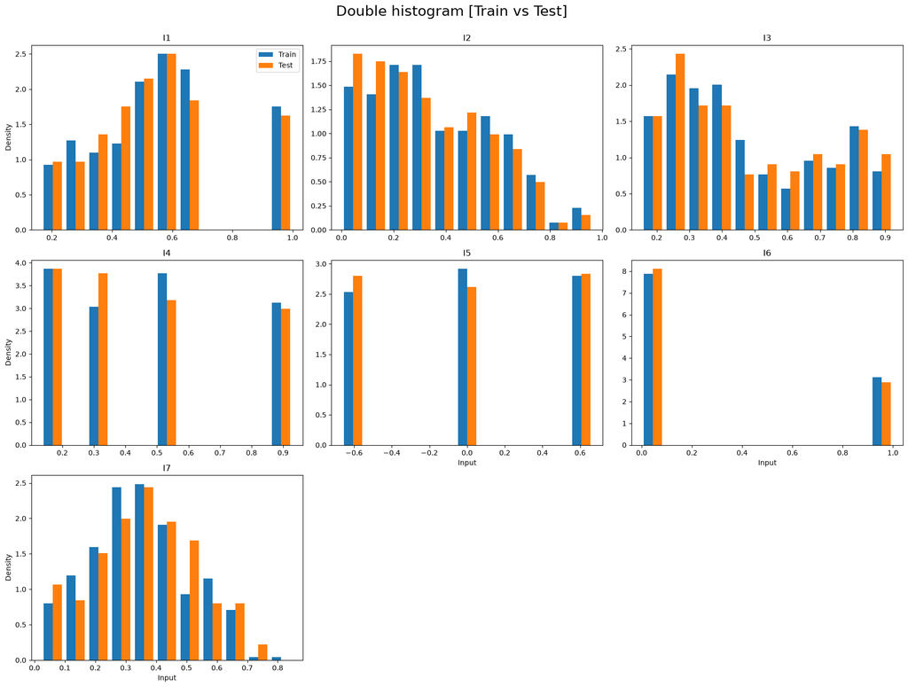

Comparison between train and test distributions of numerical variables (hypothesis tests: Kolmogorov-Smirnov and Anderson-Darling)

p-values

|  | KS | AD |
| --- | --- | --- |
| I1 | 0.94145 | 0.25000 |
| I2 | 0.65357 | 0.21639 |
| I3 | 0.84834 | 0.25000 |
| I4 | 0.78795 | 0.25000 |
| I5 | 0.99637 | 0.25000 |
| I6 | 1.00000 | 0.25000 |
| I7 | 0.12123 | 0.25000 |

```python
display(Markdown("Comparison between train and test distributions of numerical variables (histograms)"))
validationlib.plots.doubleHistogram(
    x_train_spvar_df,
    x_test_spvar_df,
    xlabel='Input',
    x1label='Train',
    x2label='Test',
    multiPlotsKwargs = {"tight_layout":True}
)
plt.show()

display(Markdown("Comparison between train and test distributions of numerical variables (hypothesis tests: Kolmogorov-Smirnov and Anderson-Darling)"))
table_pval_num = validationlib.tests.dist.dist_similarity_table(
    x_train_spvar_df,
    x_test_spvar_df,
    title="p-values",
    tests=["KS", "AD"]
)
display(table_pval_num)
```

```python
display(Markdown("### Voxel Tesselation proximity method"))
from scipy.spatial import ConvexHull
from validationlib.misc.split_validation import voxel_tesselation_proximity_method

validation_result = voxel_tesselation_proximity_method(
    x_train_spvar_df,
    x_test_spvar_df,
    compute_chmp=True,
)

display(validation_result)

if len(splitting_variables) == 2:
    hull = ConvexHull(x_train_spvar_df[splitting_variables].values)

    offset = 0.005
    var0_offset = offset * (x_test_spvar_df[splitting_variables[0]].max() - x_test_spvar_df[splitting_variables[0]].min())
    var1_offset = offset * (x_test_spvar_df[splitting_variables[1]].max() - x_test_spvar_df[splitting_variables[1]].min())

    fig, axs = plt.subplots(figsize=(10,10))

    for i, simplex in enumerate(hull.simplices):
        label = "Training CH" if i == 0 else None
        axs.plot(x_train_spvar_df.loc[simplex, splitting_variables[0]], x_train_spvar_df.loc[simplex, splitting_variables[1]], 'k:', label=label)

    axs.scatter(x_train_spvar_df[splitting_variables[0]], x_train_spvar_df[splitting_variables[1]], s=10,facecolors='none', edgecolors='k', label='Train')
    # axs.scatter(x_test_spvar_df[splitting_variables[0]], x_test_spvar_df[splitting_variables[1]], s=10, c='k', label='Test')
    axs.scatter(x_test_spvar_df[splitting_variables[0]][validation_result.isolated_test], x_test_spvar_df[splitting_variables[1]][validation_result.isolated_test], s=60, marker="x", label='Isolated test', c="b", linewidths=1)
    axs.scatter(x_test_spvar_df[splitting_variables[0]][validation_result.test_outside_ch], x_test_spvar_df[splitting_variables[1]][validation_result.test_outside_ch], s=80, marker="+", label='Outside CH', c="b", linewidths=1)
    axs.scatter(x_test_spvar_df[splitting_variables[0]][validation_result.phacking_test], x_test_spvar_df[splitting_variables[1]][validation_result.phacking_test], s=60, marker="x", label='p-hacking', c="r", linewidths=1)
    axs.scatter(x_test_spvar_df[splitting_variables[0]][validation_result.valid_test_point], x_test_spvar_df[splitting_variables[1]][validation_result.valid_test_point], s=30, marker="o", label='Valid test', c="g", linewidths=1)

    for i in x_test_spvar_df.index:
        axs.text(x_test_spvar_df.loc[i, splitting_variables[0]] + var0_offset, x_test_spvar_df.loc[i, splitting_variables[1]] + var1_offset, str(i), fontsize=8)

    axs.set_xlabel(splitting_variables[0])
    axs.set_ylabel(splitting_variables[1])

    plt.legend(bbox_to_anchor=(0.5, 1.07), loc='upper center', borderaxespad=0., ncols=3)
    plt.tight_layout()
    plt.show()
```

Voxel Tesselation proximity method

|  | Results |
| --- | --- |
| Residual Voxel Proportion | 0.0 |
| Valid Test Proportion | 0.246667 |
| Phacking Test Proportion | 0.003333 |
| Isolated Test Proportion | 0.01 |
| Test Outside CH Proportion | 0.753333 |
| Isolated Train Proportion | 0.0 |
| Chi-Squared p-Value | None |

## MODEL

Here, we plot the training curves of the model.

```python
training_curves_path = os.path.join(csv_dir, "training_curves.json")
if os.path.exists(training_curves_path):
    with open(training_curves_path, "r") as f:
        training_logs = json.load(f)

    training_metrics_dict = {"Loss": training_logs["train_loss"]}
    validation_metrics_dict = {"Loss": training_logs["test_loss"]}

    validationlib.models.validation.training_curves_plot(
        training_metrics_dict,
        validation_metrics_dict,
    )
    plt.show()
else:
    display(Markdown("*Training curves not available for this model.*"))
```

*Training curves not available for this model.*

## ERROR QUANTIFICATION

In the following sections, we study the error of the model: its overall magnitude, its distributions (conditioned to inputs and outputs), if it presents biases, etc. For that we will use two metrics: the residue and the absolute error, defined for point $i$ as follows:

$$\text{Residue}_i = y_i - \hat{y}_i$$

$$\text{AbsErr}_i = |y_i - \hat{y}_i|$$

where $y_i$ and $\hat{y}_i$ are the ground truth and predicted $c_p$ respectively for point $i$.

```python
# Definition of the metrics

residue_metric = validationlib.misc.metrics.DistanceMetrics("Residue").define_metric(lambda y_true, y_pred: y_true - y_pred)
abserr_metric = validationlib.misc.metrics.DistanceMetrics("Absolute Error").define_metric(lambda y_true, y_pred: np.abs(y_true - y_pred))
```

### Outside CH and potential p-hacking analysis

Here we perform two different comparisons:

- We compare the error distribution of the test points considered as valid against the error distribution of test points flagged with risk of p-hacking. If those flagged with risk of p-hacking have truly p-hacking, their error should be significantly lower than the error of the points considered valid.
- We compare the error distribution of the test points considered as valid against the error distribution of test points outside the training CH. Usually, test points outside the training CH will have a significantly higher error, since the model is extrapolating there.

Comparison of the points with risk of p-hacking and the valid points

Comparison using histograms

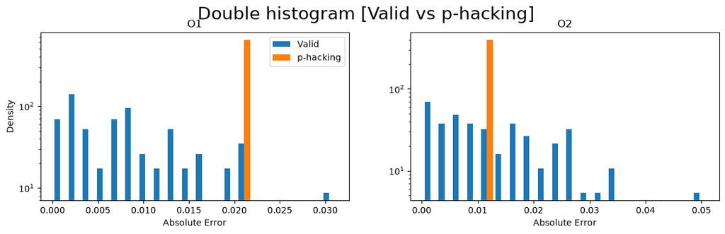

Comparison using hypothesis tests (Kolmogorov-Smirnov and Anderson-Darling)

Hypothesis Tests Results (p-value)

|  | AD | KS | KW |
| --- | --- | --- | --- |
| O1 | 0.05751 | 0.08000 | 0.10594 |
| O2 | 0.25000 | 0.98667 | 0.96316 |

Comparison of the points outside the convex hull and the valid points

Comparison using histograms

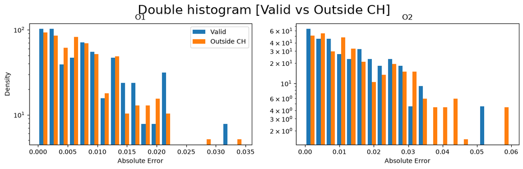

Comparison using hypothesis tests (Kolmogorov-Smirnov and Anderson-Darling

Hypothesis Tests Results (p-value)

|  | AD | KS | KW |
| --- | --- | --- | --- |
| O1 | 0.25000 | 0.57652 | 0.64544 |
| O2 | 0.25000 | 0.84668 | 0.62453 |

Comparison of the isolated points and the valid points

Comparison using histograms

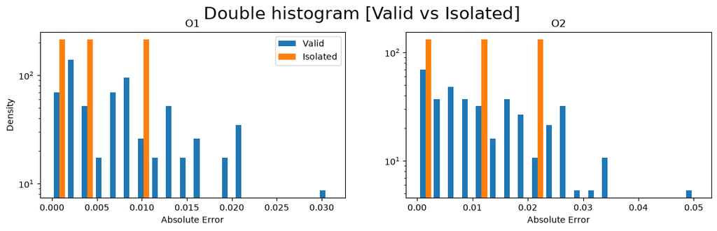

Comparison using hypothesis tests (Kolmogorov-Smirnov and Anderson-Darling

Hypothesis Tests Results (p-value)

|  | AD | KS | KW |
| --- | --- | --- | --- |
| O1 | 0.25000 | 0.92470 | 0.56249 |
| O2 | 0.25000 | 0.95981 | 0.75208 |

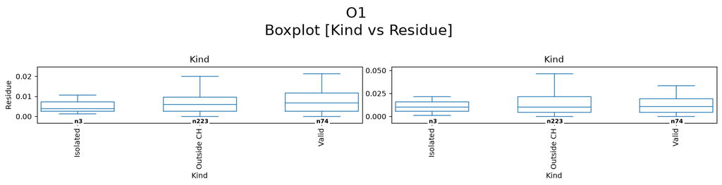

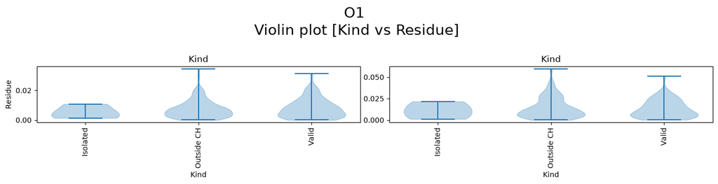

```python
vtpm_masks_df = pd.DataFrame(index=x_test_df.index, columns=["phacking", "outside_ch", "valid"])

for i in x_test_spvar_df.index:
    spvar_mask = x_test_df[splitting_variables].apply(lambda row: (row == x_test_spvar_df.loc[i, splitting_variables]).all(), axis=1)

    vtpm_masks_df.loc[spvar_mask, "phacking"] = validation_result.phacking_test[i]
    vtpm_masks_df.loc[spvar_mask, "outside_ch"] = validation_result.test_outside_ch[i]
    vtpm_masks_df.loc[spvar_mask, "valid"] = validation_result.valid_test_point[i]
    vtpm_masks_df.loc[spvar_mask, "isolated"] = validation_result.isolated_test[i]

if vtpm_masks_df["phacking"].any():
    display(Markdown("### Comparison of the points with risk of p-hacking and the valid points"))
    display(Markdown("Comparison using histograms"))
    validationlib.plots.doubleHistogram(
        abserr_metric(yt_test_df, yh_test_df)[vtpm_masks_df["valid"]],
        abserr_metric(yt_test_df, yh_test_df)[vtpm_masks_df["phacking"]],
        xlabel=abserr_metric.name,
        x1label='Valid',
        x2label='p-hacking',
        bins=20,
        logscale=True,
    )
    plt.show()

    display(Markdown("Comparison using hypothesis tests (Kolmogorov-Smirnov and Anderson-Darling)"))
    displayed_table = validationlib.tests.dist.dist_similarity_table(
        abserr_metric(yt_test_df, yh_test_df)[vtpm_masks_df["valid"]],
        abserr_metric(yt_test_df, yh_test_df)[vtpm_masks_df["phacking"]],
        title="Hypothesis Tests Results (p-value)",
        tests=["AD", "KS", "KW"]
    )
    display(displayed_table)
else:
    display(Markdown("#### No points with risk of p-hacking found in the test set."))

if vtpm_masks_df["outside_ch"].any():
    display(Markdown("### Comparison of the points outside the convex hull and the valid points"))
    display(Markdown("Comparison using histograms"))
    validationlib.plots.doubleHistogram(
        abserr_metric(yt_test_df, yh_test_df)[vtpm_masks_df["valid"]],
        abserr_metric(yt_test_df, yh_test_df)[vtpm_masks_df["outside_ch"]],
        xlabel=abserr_metric.name,
        x1label='Valid',
        x2label='Outside CH',
        bins=20,
        logscale=True
    )
    plt.show()

    display(Markdown("Comparison using hypothesis tests (Kolmogorov-Smirnov and Anderson-Darling"))
    displayed_table = validationlib.tests.dist.dist_similarity_table(
        abserr_metric(yt_test_df, yh_test_df)[vtpm_masks_df["valid"]],
        abserr_metric(yt_test_df, yh_test_df)[vtpm_masks_df["outside_ch"]],
        title="Hypothesis Tests Results (p-value)",
        tests=["AD", "KS", "KW"]
    )
    display(displayed_table)
else:
    display(Markdown("#### No points outside the training convex hull found in the test set."))

if vtpm_masks_df["isolated"].any():
    display(Markdown("### Comparison of the isolated points and the valid points"))
    display(Markdown("Comparison using histograms"))
    validationlib.plots.doubleHistogram(
        abserr_metric(yt_test_df, yh_test_df)[vtpm_masks_df["valid"]],
        abserr_metric(yt_test_df, yh_test_df)[vtpm_masks_df["isolated"]],
        xlabel=abserr_metric.name,
        x1label='Valid',
        x2label='Isolated',
        bins=20,
        logscale=True
    )
    plt.show()

    display(Markdown("Comparison using hypothesis tests (Kolmogorov-Smirnov and Anderson-Darling"))
    displayed_table = validationlib.tests.dist.dist_similarity_table(
        abserr_metric(yt_test_df, yh_test_df)[vtpm_masks_df["valid"]],
        abserr_metric(yt_test_df, yh_test_df)[vtpm_masks_df["isolated"]],
        title="Hypothesis Tests Results (p-value)",
        tests=["AD", "KS", "KW"]
    )
    display(displayed_table)
else:
    display(Markdown("#### No points outside the training convex hull found in the test set."))

if vtpm_masks_df["phacking"].any() or vtpm_masks_df["outside_ch"].any() or vtpm_masks_df["isolated"].any():
    vtpm_masks_df_classes = pd.DataFrame(index=x_test_df.index, columns=["Kind"])
    vtpm_masks_df_classes.loc[vtpm_masks_df["phacking"], "Kind"] = "p-hacking"
    vtpm_masks_df_classes.loc[vtpm_masks_df["outside_ch"], "Kind"] = "Outside CH"
    vtpm_masks_df_classes.loc[vtpm_masks_df["valid"], "Kind"] = "Valid"
    vtpm_masks_df_classes.loc[vtpm_masks_df["isolated"], "Kind"] = "Isolated"

    validationlib.plots.boxplot(
        vtpm_masks_df_classes,
        abserr_metric(yt_test_df, yh_test_df),
        categorical=True,
        var_y = yt_test_df.columns[0], # Name of the output variable
        xlabel = 'Kind',
        ylabel = residue_metric.name,
        showfliers = False,
        # trimStds=3,
        multiPlotsKwargs = {'tight_layout': True}
    )
    plt.show()

    validationlib.plots.violinPlot(
        vtpm_masks_df_classes,
        abserr_metric(yt_test_df, yh_test_df),
        categorical=True,
        var_y = yt_test_df.columns[0], # Name of the output variable
        xlabel = 'Kind',
        ylabel = residue_metric.name,
        showextrema=True,
        # trimStds=3,
        multiPlotsKwargs = {'tight_layout': True}
    )
    plt.show()
```

### Pointwise error metrics

Here we study the general aspects of the model's error.

#### RESIDUE

Confidence level at 95%. BS=Confidence Interval (percentile bootstrap)

|  | count | min | max | mean | (BS)mean | median | (BS)median | std | (BS)std | IQR | (BS)IQR | kurtosis | (BS)kurtosis | skewness | (BS)skewness |
| --- | --- | --- | --- | --- | --- | --- | --- | --- | --- | --- | --- | --- | --- | --- | --- |
| O1 | 300 | -0.0345 | 0.0214 | -0.000552 | <sup>0.000574</sup><sub>-0.00158</sub> | -0.000321 | <sup>0.00135</sup><sub>-0.00129</sub> | 0.0098 | <sup>0.0107</sup><sub>0.00894</sub> | 0.0129 | <sup>0.0141</sup><sub>0.0113</sub> | 0.682 | <sup>1.41</sup><sub>-0.183</sub> | -0.422 | <sup>-0.0759</sup><sub>-0.744</sub> |
| O2 | 300 | -0.0578 | 0.0595 | 0.00041 | <sup>0.00217</sup><sub>-0.00137</sub> | 0.000627 | <sup>0.00239</sup><sub>-0.002</sub> | 0.0183 | <sup>0.0202</sup><sub>0.0167</sub> | 0.0212 | <sup>0.0244</sup><sub>0.0188</sub> | 0.466 | <sup>1.20</sup><sub>-0.198</sub> | 0.144 | <sup>0.475</sup><sub>-0.177</sub> |

Confidence level at 95%. BS=Confidence Interval (percentile bootstrap)

|  | 1% | (BS)1% | 5% | (BS)5% | 10% | (BS)10% | 50% | (BS)50% | 90% | (BS)90% | 95% | (BS)95% | 99% | (BS)99% |
| --- | --- | --- | --- | --- | --- | --- | --- | --- | --- | --- | --- | --- | --- | --- |
| O1 | -0.0292 | <sup>-0.0205</sup><sub>-0.0335</sub> | -0.0172 | <sup>-0.0141</sup><sub>-0.0202</sub> | -0.0129 | <sup>-0.0110</sup><sub>-0.0158</sub> | -0.000321 | <sup>0.00144</sup><sub>-0.00110</sub> | 0.0105 | <sup>0.0128</sup><sub>0.00915</sub> | 0.0135 | <sup>0.0189</sup><sub>0.0123</sub> | 0.021 | <sup>0.0214</sup><sub>0.0198</sub> |
| O2 | -0.0409 | <sup>-0.0332</sup><sub>-0.0467</sub> | -0.0297 | <sup>-0.0269</sup><sub>-0.0332</sub> | -0.0243 | <sup>-0.0177</sup><sub>-0.0276</sub> | 0.000627 | <sup>0.00238</sup><sub>-0.00199</sub> | 0.0252 | <sup>0.0271</sup><sub>0.0199</sub> | 0.0311 | <sup>0.0354</sup><sub>0.0261</sub> | 0.0437 | <sup>0.0583</sup><sub>0.0377</sub> |

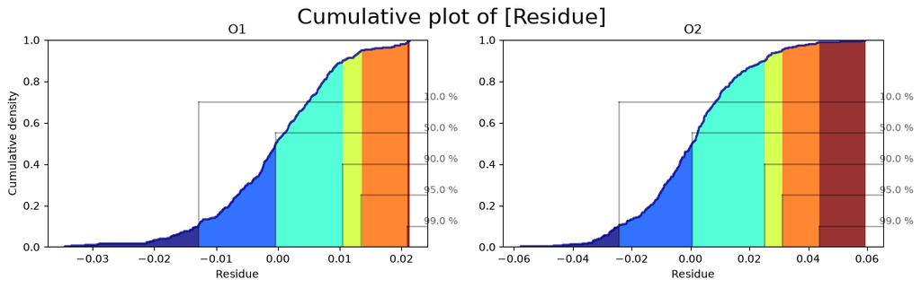

```python
# Summary of metric's statistics. Desired statistics are given as a dictionary.
# Confidence intervals of specified statistics are calculated using the bootstrap method.
statistics = {
    "mean": np.mean,
    "median": [np.percentile, {"q": 50}],
    "std": np.std,
    "IQR": st.iqr,
    "kurtosis": st.kurtosis,
    "skewness": st.skew
}
displayed_table = validationlib.tables.summary.prediction_stats(
    residue_metric(yt_test_df, yh_test_df), # Metric from which the statistics are calculated
    statistics=statistics, # Dictionary of statistics to calculate
    precision=3, # Number of decimal places to display in the table
    nsim=100, # Number of simulations for the bootstrap method
    method='Bootstrap' # Method used to calculate the confidence intervals.
)
display(displayed_table)

# Cumulative distribution of the metric (table)
statistics_percentile = {"%i%%" % i: [np.percentile, {"q": i}] for i in [1,5,10,50,90,95,99]} # Dict of percentiles to calculate
displayed_table = validationlib.tables.summary.prediction_stats(
    residue_metric(yt_test_df, yh_test_df),
    statistics=statistics_percentile,
    precision=3,
    nsim=100,
    method='Bootstrap',
    countMinMax=False
)
display(displayed_table)

# Cumulative distribution of the metric (plot)
validationlib.plots.cumulative(
    residue_metric(yt_test_df, yh_test_df),
    xlabel=residue_metric.name,
    bins=1000,
    quantiles=[0.1, 0.50, 0.90, 0.95, 0.99] # Quantiles to display in the plot
)
plt.show()
```

#### ABS. ERR.

```python
# Summary of metric's statistics. Desired statistics are given as a dictionary.
# Confidence intervals of specified statistics are calculated using the bootstrap method.
statistics = {
    "mean": np.mean,
    "median": [np.percentile, {"q": 50}],
    "std": np.std,
    "IQR": st.iqr,
    "kurtosis": st.kurtosis,
    "skewness": st.skew
}
displayed_table = validationlib.tables.summary.prediction_stats(
    abserr_metric(yt_test_df, yh_test_df), # Metric from which the statistics are calculated
    statistics=statistics, # Dictionary of statistics to calculate
    precision=3, # Number of decimal places to display in the table
    nsim=100, # Number of simulations for the bootstrap method
    method='Bootstrap' # Method used to calculate the confidence intervals.
)
display(displayed_table)

# Cumulative distribution of the metric (table)
statistics_percentile = {"%i%%" % i: [np.percentile, {"q": i}] for i in [1,5,10,50,90,95,99]} # Dict of percentiles to calculate
displayed_table = validationlib.tables.summary.prediction_stats(
    abserr_metric(yt_test_df, yh_test_df),
    statistics=statistics_percentile,
    precision=3,
    nsim=100,
    method='Bootstrap',
    countMinMax=False
)
display(displayed_table)
```

Confidence level at 95%. BS=Confidence Interval (percentile bootstrap)

|  | count | min | max | mean | (BS)mean | median | (BS)median | std | (BS)std | IQR | (BS)IQR | kurtosis | (BS)kurtosis | skewness | (BS)skewness |
| --- | --- | --- | --- | --- | --- | --- | --- | --- | --- | --- | --- | --- | --- | --- | --- |
| O1 | 300 | 0.0000275 | 0.0345 | 0.00758 | <sup>0.00821</sup><sub>0.00676</sub> | 0.00639 | <sup>0.00720</sup><sub>0.00544</sub> | 0.00624 | <sup>0.00695</sup><sub>0.00553</sub> | 0.00756 | <sup>0.00964</sup><sub>0.00633</sub> | 2.38 | <sup>4.22</sup><sub>0.821</sub> | 1.38 | <sup>1.72</sup><sub>1.00</sub> |
| O2 | 300 | 0.0000601 | 0.0595 | 0.0141 | <sup>0.0149</sup><sub>0.0129</sub> | 0.0106 | <sup>0.0121</sup><sub>0.00967</sub> | 0.0117 | <sup>0.0126</sup><sub>0.0107</sub> | 0.0168 | <sup>0.019</sup><sub>0.0129</sub> | 1.35 | <sup>2.47</sup><sub>0.0394</sub> | 1.19 | <sup>1.53</sup><sub>0.915</sub> |

Confidence level at 95%. BS=Confidence Interval (percentile bootstrap)

|  | 1% | (BS)1% | 5% | (BS)5% | 10% | (BS)10% | 50% | (BS)50% | 90% | (BS)90% | 95% | (BS)95% | 99% | (BS)99% |
| --- | --- | --- | --- | --- | --- | --- | --- | --- | --- | --- | --- | --- | --- | --- |
| O1 | 0.000102 | <sup>0.000340</sup><sub>0.0000514</sub> | 0.000551 | <sup>0.000841</sup><sub>0.000383</sub> | 0.0012 | <sup>0.00165</sup><sub>0.000823</sub> | 0.00639 | <sup>0.00700</sup><sub>0.00553</sub> | 0.0161 | <sup>0.0178</sup><sub>0.0138</sub> | 0.0201 | <sup>0.021</sup><sub>0.0179</sub> | 0.0292 | <sup>0.0335</sup><sub>0.0213</sub> |
| O2 | 0.000269 | <sup>0.000511</sup><sub>0.0000875</sub> | 0.00124 | <sup>0.00194</sup><sub>0.000601</sub> | 0.00217 | <sup>0.00283</sup><sub>0.00191</sub> | 0.0106 | <sup>0.0122</sup><sub>0.00924</sub> | 0.0303 | <sup>0.0325</sup><sub>0.0272</sub> | 0.0348 | <sup>0.0428</sup><sub>0.0315</sub> | 0.051 | <sup>0.0589</sup><sub>0.0417</sub> |

#### PREDICTED vs GROUND TRUTH

Comparison between the distributionss of true and predicted outputs. These distributions should be as close as possible.

Comparison using histograms

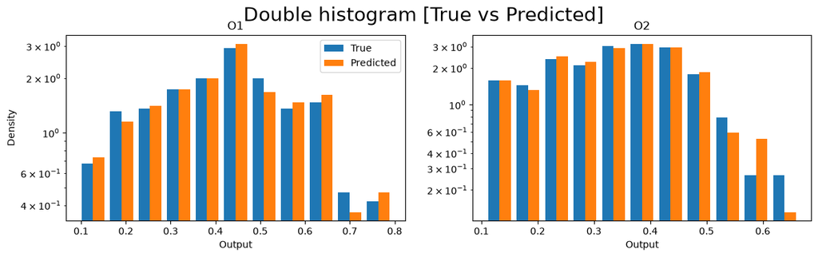

Comparison using hypothesis tests (Kolmogorov-Smirnov and Anderson-Darling)

Hypothesis Tests Results (p-value)

|  | AD | KS |
| --- | --- | --- |
| O1 | 0.25000 | 1.00000 |
| O2 | 0.25000 | 0.99637 |

```python
display(Markdown("Comparison using histograms"))
validationlib.plots.doubleHistogram(
    yt_test_df,
    yh_test_df,
    xlabel='Output',
    x1label='True',
    x2label='Predicted',
    logscale=True
)
plt.show()

display(Markdown("Comparison using hypothesis tests (Kolmogorov-Smirnov and Anderson-Darling)"))
displayed_table = validationlib.tests.dist.dist_similarity_table(
    yt_test_df,
    yh_test_df,
    title="Hypothesis Tests Results (p-value)",
    tests=["AD", "KS"]
)
display(displayed_table)
```

Predicted vs true scatterplot and 2D histogram. This plots should be as close to the identity line as possible.

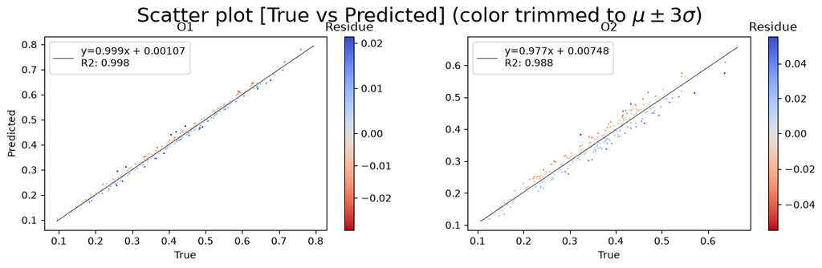

```python
display(Markdown("Predicted vs true scatterplot and 2D histogram. This plots should be as close to the identity line as possible."))

validationlib.plots.scatterplot(
    yt_test_df,
    yh_test_df,
    c=residue_metric(yt_test_df, yh_test_df), # The metric is used to color the points
    correlationAxis="fit", # This displays a linear fit and a "normalized" slope (should be as close to 1 as possible)
    fit_info="default",
    significant_figures=3,
    xlabel="True",
    ylabel="Predicted",
    clabel=residue_metric.name,
    cmapCenter=residue_metric.neutral, # The color map is centered around the neutral value of the metric (the value that is considered "good", e.g. 0 for Residue)
    trimStds=3 # This trims the color map to the range of values within 3 standard deviations of the mean
)
plt.show()
```

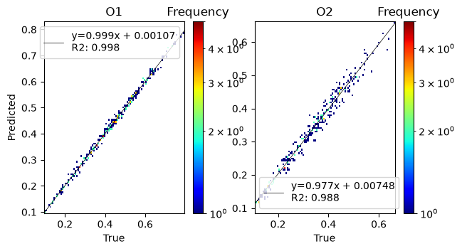

```python
validationlib.plots.hist2D(
    yt_test_df,
    yh_test_df,
    bins=100,
    xlabel="True",
    ylabel="Predicted",
    scale="frequency",
    correlationAxis="fit",
    logscale=True,
    figHsize=7,
    figAspectRatio=2
)
plt.show()
```

### P(E)

Here we study the marginal distribution of the error (not conditioned). For that we employ an AD test to compare the distribution of the error metric to some well known parametric distributions.

If a fit is detected, we further study the quality of said fit.

If the fit is determined to be appropriate, we can use the newly fit parametric distribution to characterize the model's error (e.g. outlier detection).

#### RESIDUE

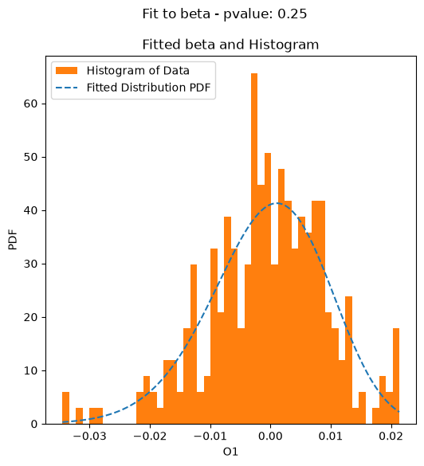

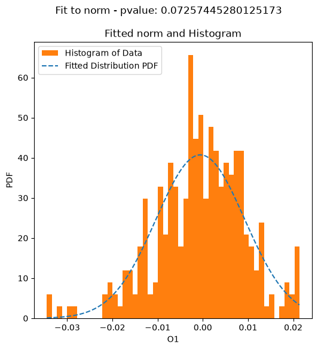

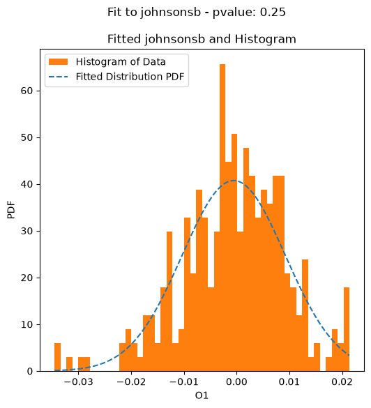

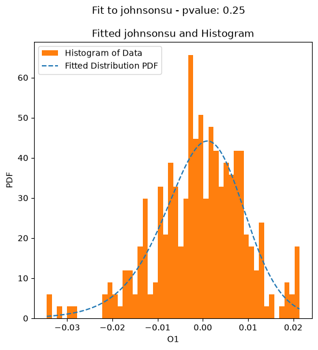

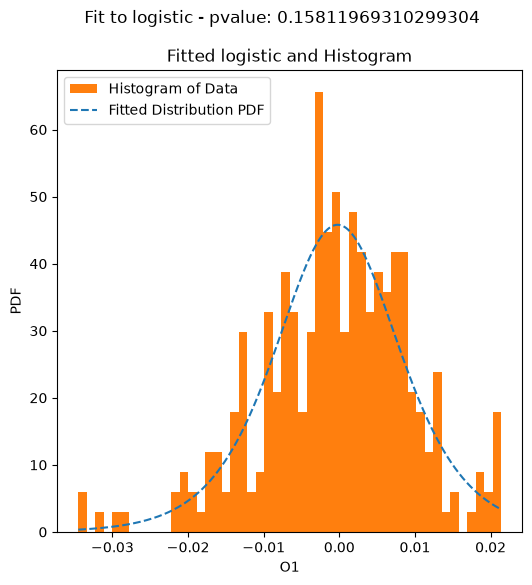

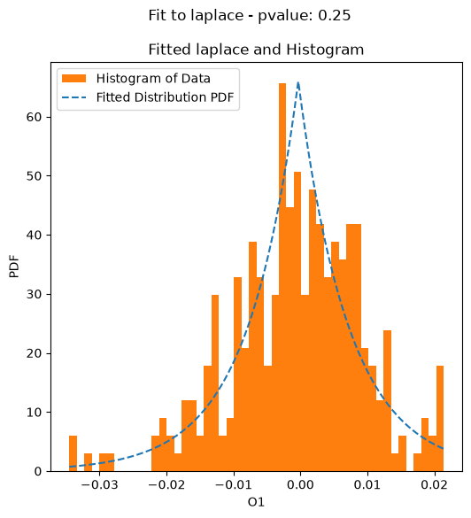

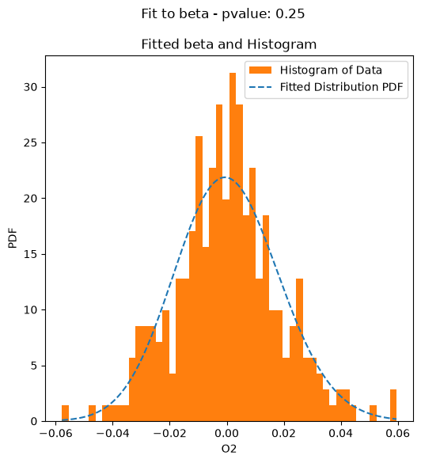

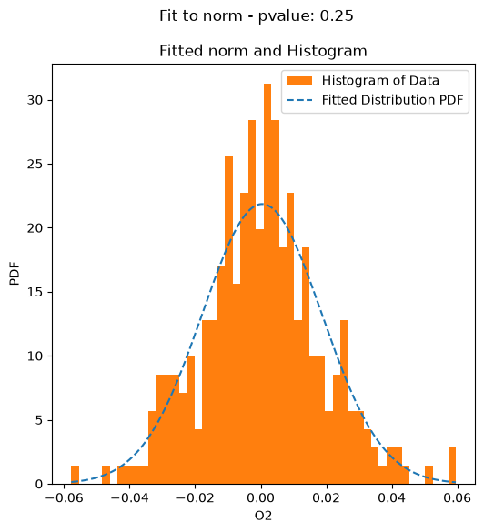

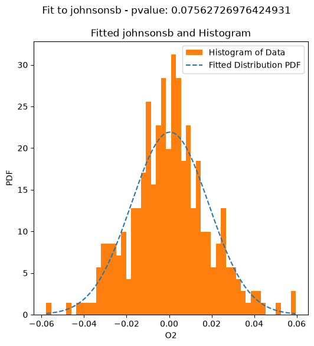

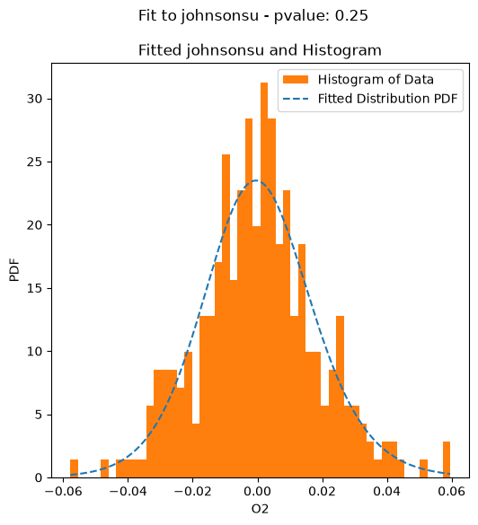

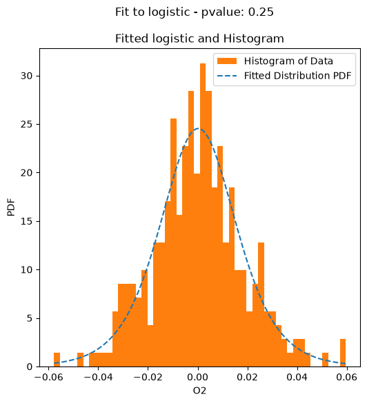

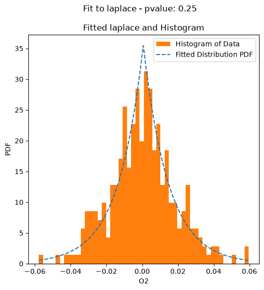

Fit to each output-metric (quick-method)

|  | Beta | Norm | Johnsonsb | Johnsonsu | Logistic | Cauchy | Laplace |
| --- | --- | --- | --- | --- | --- | --- | --- |
| O1 | 0.250 | 0.073 | 0.250 | 0.250 | 0.158 | 0.014 | 0.250 |
| O2 | 0.250 | 0.250 | 0.076 | 0.250 | 0.250 | 0.046 | 0.250 |

```python
# Goodness of fit tests. These tests compare the distribution of the defined metric to a parametric distribution.
# This can be used with any parametric distribution from scipy.stats.

# This cell exectues the tests using a quick method
# Quick method has a large variability in the results for small to medium sample sizes (try running this cell multiple times to see how the results change)
# If this behavior is observed, it is recommended to use the robust method, which is more computationally expensive
displayed_table, df = validationlib.tables.summary.fit_distribution_similarity(
    residue_metric(yt_test_df, yh_test_df),
    test = 'AD', # Anderson-Darling test to compare the distributions
    method="quick",
    dist = validationlib.tests.dist.COMMON_DISTS, # List of commonly used distributions
    title="Fit to each output-metric (quick-method)",
    robust_kwargs={"n_mc_samples": 1000},
    plot_fits=True
)
display(displayed_table)
```